# bellabeats_project_final

Archit

06/07/2021

BellaBeat is a high-tech manufacturer of health-focused products for women. Bellabeat is a successful small company, but they have the potential to become a larger player in the global smart device market.

Role: hypothetical junior data analyst. Stakeholders: marketing team, executive team and founders:- Urska Sersen, Sando Mur. Business task: to clean, analyse and visualize data and gain insights and give recommendations to stakeholders using visualizations to support findings Data sourse: Kaggle

Data Set name: FitBit Fitness Tracker Data Dataset Info: The data set has 18 csv files. The dataset was created by Mobius. Limitations: The data does not include demographic information such has gender, age, nationality etc The sample size are small as it only captured 30 users information. The dataset was outdated as the survey was conducted in 2016. The dataset was not first hand data. The data collection period was short as the duration was only 1 month. Too many missing value.

# Starting By Importing Data

```r
library(tidyverse)
#install.packages("readxl")
library(readxl)
dailyActivity.33 <-read_excel("C:\\Users\\archi\\OneDrive\\Desktop\\New folder\\dailyActivity.xlsx")
calory_burn_per_day <- read_excel("C:\\Users\\archi\\OneDrive\\Desktop\\New folder\\calory_burn_per_day.xlsx")
Intensity_hour <- read_excel("C:\\Users\\archi\\OneDrive\\Desktop\\New folder\\Intensity_hour.xlsx")
sleep_day.24 <- read_excel("C:\\Users\\archi\\OneDrive\\Desktop\\New folder\\sleep_day.xlsx")
steps_walked_per_day.33 <- read_excel("C:\\Users\\archi\\OneDrive\\Desktop\\New folder\\steps_walked_per_day.xlsx")
steps_walked_per_day.33
```

```
## # A tibble: 940 x 3
##            Id ActivityDay StepTotal
##         <dbl> <chr>           <dbl>
##  1 1503960366 42708           13162
##  2 1503960366 4/13/2016       10735
##  3 1503960366 4/14/2016       10460
##  4 1503960366 4/15/2016        9762
##  5 1503960366 4/16/2016       12669
##  6 1503960366 4/17/2016        9705
##  7 1503960366 4/18/2016       13019
##  8 1503960366 4/19/2016       15506
##  9 1503960366 4/20/2016       10544
## 10 1503960366 4/21/2016        9819
## # ... with 930 more rows
```

now the required data has been imported,

#checking if the data has N/A values,outliers and is consistent or not.

```r
# checking for missing values
steps_walked_per_day.33 %>% count(Id)
```

```
## # A tibble: 33 x 2
##            Id     n
##         <dbl> <int>
##  1 1503960366    31
##  2 1624580081    31
##  3 1644430081    30
##  4 1844505072    31
##  5 1927972279    31
##  6 2022484408    31
##  7 2026352035    31
##  8 2320127002    31
##  9 2347167796    18
## 10 2873212765    31
## # ... with 23 more rows
```

```r
sleep_day.24 %>% count(Id)
```

```
## # A tibble: 24 x 2
##            Id     n
##         <dbl> <int>
##  1 1503960366    25
##  2 1644430081     4
##  3 1844505072     3
##  4 1927972279     5
##  5 2026352035    28
##  6 2320127002     1
##  7 2347167796    15
##  8 3977333714    28
##  9 4020332650     8
## 10 4319703577    26
## # ... with 14 more rows
```

```r
Intensity_hour %>% count(Id)
```

```
## # A tibble: 33 x 2
##            Id     n
##         <dbl> <int>
##  1 1503960366   717
##  2 1624580081   736
##  3 1644430081   708
##  4 1844505072   731
##  5 1927972279   736
##  6 2022484408   736
##  7 2026352035   736
##  8 2320127002   735
##  9 2347167796   414
## 10 2873212765   736
## # ... with 23 more rows
```

```r
dailyActivity.33 %>% count(Id)
```

```
## # A tibble: 33 x 2
##            Id     n
##         <dbl> <int>
##  1 1503960366    31
##  2 1624580081    31
##  3 1644430081    30
##  4 1844505072    31
##  5 1927972279    31
##  6 2022484408    31
##  7 2026352035    31
##  8 2320127002    31
##  9 2347167796    18
## 10 2873212765    31
## # ... with 23 more rows
```

```r
calory_burn_per_day %>% count(Id)
```

```
## # A tibble: 33 x 2
##            Id     n
##         <dbl> <int>
##  1 1503960366    31
##  2 1624580081    31
##  3 1644430081    30
##  4 1844505072    31
##  5 1927972279    31
##  6 2022484408    31
##  7 2026352035    31
##  8 2320127002    31
##  9 2347167796    18
## 10 2873212765    31
## # ... with 23 more rows
```

on noticing that a few Ids have insufficient data, i decide to remove those Ids from the data before analysing it # Removing misleading and incomplete data

```r
# removing ids with insufficientd data
step_clean1 <- subset(steps_walked_per_day.33, Id!=2347167796 & Id!=3372868164 & Id!=4057192912 & Id!=8253242879)
Intensity_clean1 <- subset(Intensity_hour, Id!=2347167796 & Id!=3372868164 & Id!=4057192912 & Id!=8253242879)
activity_clean1 <- subset(dailyActivity.33, Id!=2347167796 & Id!=3372868164 & Id!=4057192912 & Id!=8253242879)
calory_clean1 <- subset(calory_burn_per_day, Id!=2347167796 & Id!=3372868164 & Id!=4057192912 & Id!=8253242879)
```

# Transforming data into usable form for analysis

```r
# transforming and summarizing data for analysis
step_clean2 <- (step_clean1 %>%
                  group_by(Id) %>%
                  summarise(step_per_day_avr= mean(StepTotal)))
sleep_clean1 <- (sleep_day.24 %>%
                   group_by(Id) %>%
                   summarise(sleep_avr = mean(TotalMinutesAsleep)))
calory_clean2 <- (calory_clean1 %>%
                    group_by(Id) %>%
                    summarise(calory_avr = mean(Calories)))
#making the date time to correct format
Intensity_clean1$ActivityHour=as.POSIXct(Intensity_clean1$ActivityHour, format="%m/%d/%Y %I:%M:%S %p", tz=Sys.timezone())
# divide the column to 2 separate columns
Intensity_clean1$time <- format(Intensity_clean1$ActivityHour, format = "%H:%M:%S")
Intensity_clean1$date <- format(Intensity_clean1$ActivityHour, format = "%m/%d/%y")
Intensity_clean2 <- (Intensity_clean1 %>%
                       group_by(time) %>%
                       summarise(Inten_avr = mean(TotalIntensity)))
```

# To analyse WALKING PATERNS in detail

## grouping ids by number of steps walked

```r
# finding out who completes atleast 10k steps by mutating a column
step_clean3 <- (step_clean2 %>%
                  mutate(step_group = case_when(step_per_day_avr<=7000 ~ "Group1(7k or below)",
                                                step_per_day_avr>7000 & step_per_day_avr<=8000 ~ "Group2(8k)",
                                                step_per_day_avr>8000 & step_per_day_avr<=9000 ~  "Group3(9k)",
                                                step_per_day_avr>9000 & step_per_day_avr<=10000 ~ "Group4(10k)",
                                                step_per_day_avr>10000 ~ "Group5(above 10k)")))
step_clean4 <- (step_clean3 %>%
                  group_by(step_group)%>%
                  summarise(count = n()))
```

visualising the data using a bar-graph :

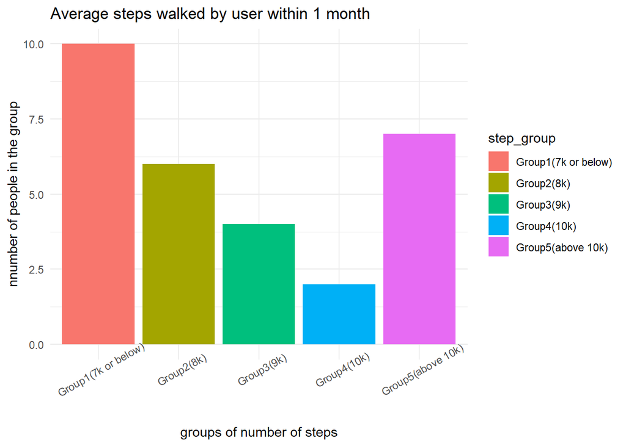

```r
ggplot(data=step_clean4, aes(x=step_group, y=count, fill=step_group)) +
  geom_bar(stat="identity")+
  theme_minimal()  +
  ggtitle("Average steps walked by user within 1 month") +
  theme(axis.text.x = element_text(angle=30))+
  labs(x="groups of number of steps", y="nnumber of people in the group")
```

According to Fitbit experts the minimum number of steps that a person should walk is 10k. By observing the above graph we can infere that a significant number of people fall in the “less than 7k” category. the lowest observation is in the 9-10k steps category.

# Now analysing sleeping patterns

```r
sleep_clean2 <- sleep_clean1 %>% mutate(sleep_hour= sleep_avr/60)
sleep_clean3 <- (sleep_clean2 %>%
                   mutate(sleep_group = case_when(sleep_hour<=4 ~ "Group1(4h or below)",
                                                  sleep_hour>4 & sleep_hour<=5 ~ "Group2(5h)",
                                                  sleep_hour>5 & sleep_hour<=6 ~  "Group3(6h)",
                                                  sleep_hour>6 & sleep_hour<=7 ~ "Group4(7h)",
                                                  sleep_hour>7 & sleep_hour<=8 ~ "Group5(8h)",
                                                  sleep_hour>8 ~ "Group6(8h or above)")))
sleep_clean4 <- (sleep_clean3 %>%
                   group_by(sleep_group)%>%
                   summarise(count = n()))
```

visualising the above data to gain insights:

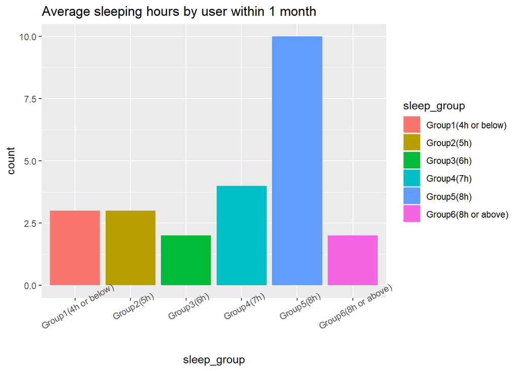

```r
ggplot(data= sleep_clean4 , aes(x= sleep_group , y=  count, fill = sleep_group))+geom_bar(stat= "identity")+
  theme(axis.text.x = element_text(angle = 30))+ ggtitle("Average sleeping hours by user within 1 month")
```

```r
less_sleep <- nrow(subset(sleep_clean2, sleep_hour < "7"))
less_sleep
```

```
## [1] 13
```

```r
total_ids <- nrow(sleep_clean2)
total_ids
```

```
## [1] 24
```

```r
sleep_deficient_per <- (less_sleep/total_ids)*100
sleep_deficient_per
```

```
## [1] 54.16667
```

# To analyse the time taken to fall asleep

```r
fall_asleep1 <- sleep_day.24 %>% mutate(asleep_min = TotalTimeInBed-TotalMinutesAsleep)
fall_asleep2 <- (fall_asleep1 %>%
                   group_by(Id) %>%
                   summarise(average_asleep = mean(asleep_min)))
View(fall_asleep2)
#to remove outliers
fall_asleep3 <- subset(fall_asleep2, Id!=1844505072 & Id!=3977333714)
```

visualise data using a boxplot for better understandings:

```r
med = round(median(fall_asleep3$average_asleep),0)
mn= mean(fall_asleep3$average_asleep)
mn
```

```
## [1] 24.64828
```

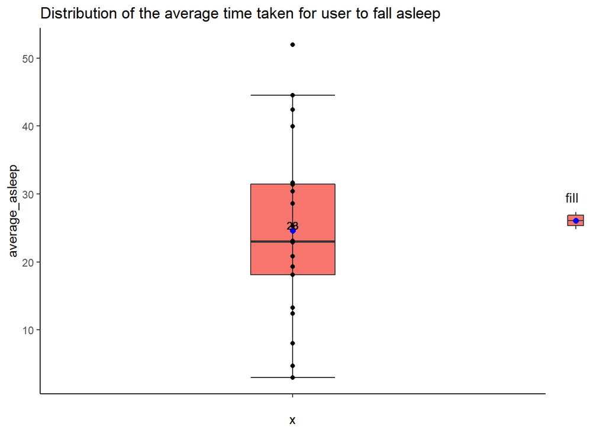

```r
ggplot(data = fall_asleep3, aes( x="",y=average_asleep, fill="")) +
  geom_boxplot(width=0.2) +geom_point()+
  labs(title = "Distribution of the average time taken for user to fall asleep")+
  theme_classic() +stat_boxplot(geom = "errorbar", width = 0.20)+
  stat_summary(fun=mean, geom = "point", colour="blue", size=2)+
  geom_text(data = fall_asleep3, aes(x = "", y = med, label =med),
              size = 3, vjust = -1.5)
```

on average it takes 23-24 minutes for an individual to all asleep after in bed.